# scRNAseq_CITEseq_ind_NormalizeData

Dernière modification : 05 octobre, 2022

Laëtitia Racine

15/12/2021

```r
library(dplyr)
library(Seurat)
```

```r
library(ggplot2)
library(gridExtra) # function grid.arrange()
library(grid) # function textGrob()
library(sctransform)
library(matrixStats) # function rowMedians()
library(kableExtra)

# BiocManager::install("glmGamPoi")
```

# .Objectif du code

Ce code **permet de** :

- I : normaliser les objets Seurat avec les fonctions de base de Seurat (assay : “RNA”) https://satijalab.org/seurat/articles/pbmc3k_tutorial.html https://satijalab.org/seurat/reference/normalizedata  
  https://satijalab.org/seurat/reference/findvariablefeatures  
  https://satijalab.org/seurat/reference/scaledata
- II : visualiser les effets du cycle cellulaire et appliquer une régression si nécessaire https://satijalab.org/seurat/articles/cell_cycle_vignette.html https://hbctraining.github.io/scRNA-seq/lessons/06_SC_SCT_and_integration.html https://nbisweden.github.io/workshop-scRNAseq/labs/compiled/seurat/seurat_01_qc.html#Calculate_cell-cycle_scores https://satijalab.org/seurat/archive/v3.1/cell_cycle_vignette.html
- III : normaliser les objets Seurat avec SCTransform (assay : “SCT”) https://chipster.csc.fi/manual/single-cell-seurat-sctransform.html https://satijalab.org/seurat/articles/sctransform_vignette.html https://www.biostars.org/p/446554/ https://cran.r-project.org/web/packages/sctransform/sctransform.pdf https://rdrr.io/cran/sctransform/man/vst.html
- IV : normaliser les données issues du CITEseq (assay : “ADT) https://satijalab.org/seurat/articles/multimodal_vignette.html

L’ordre est ici important. Comme indiqué dans l’issue : https://github.com/satijalab/seurat/issues/1679, il convient de faire d’abord la normalisation classique, puis le CellCycleScoring et ansuite d’ajouter le cell cycle scores dans vars.to.regress dans la normalisation SCTransform. On obtient **en sortie** des objets Seurat dont l’influence du cycle cellulaire a été enlevée et avec deux types de normalisation acessibles en changeant l’assay de travail. Pour la suite des “downstream analysis”, il est conseillé de travailler avec l’assay “SCT”.

```r
# Load working directories
directory = "/home/rparmentier/Bureau/Git_Metabo_Analysis/"
directory_exp = paste0(directory, "exp/")
directory_data = paste0(directory, "data/scRNAseq/")
directory_bin = paste0(directory, "bin/")

# Create a unique folder for output corresponding to the date of the day
current_date = format(Sys.time(), "%Y%m%d")
dir.create(path = paste0(directory_exp,"scRNAseq_CITEseq_ind_NormalizeData/"))
dir.create(path = paste0(directory_exp,"scRNAseq_CITEseq_ind_NormalizeData/", current_date))
directory_output = paste0(directory_exp, "scRNAseq_CITEseq_ind_NormalizeData/", current_date, "/")

# Load external script with functions and constantes
source(file = paste0(directory_bin, "functions_constantes.R"))
```

```r
# Load seurat objects
dir = pic_last_dir(paste0(directory_exp, "scRNAseq_CITEseq_ind_FilterData/"))
list_seurat_obj = readRDS(paste0(dir, "/", "list_seurat_obj_qc.rds"))
number_conditions = length(list_seurat_obj)
```

# Normalisation de l’assay RNA avec Seurat

## NormalizeData()

NormalizeData() avec la méthode “LogNormalize” : soit x le nombre d’UMI d’un gène détecté dans une cellule. Pour normaliser cette donnée, on divise x par la somme de tous les UMIs détectés pour tous les gènes de cette cellule. Il est ensuite multiplié par le *scaling factor* qui est par défaut à 10 000. On ajoute 1 au résultat et on calcule ensuite son logarithme naturel (ln). (source de l’explication du calcul : https://github.com/satijalab/seurat/issues/3630).  
“LogNormalize scales the data by library size so it eliminates the confounding effect of different read depth across the cells.”

```r
list_seurat_obj = lapply(list_seurat_obj, function(x) {
  NormalizeData(object = x,
                assay = "RNA",
                normalization.method = "LogNormalize",
                scale.factor = 10000,
                verbose = TRUE)
})
```

## FindVariableFeatures()

FindVariableFeatures() sélectionne un sous-échantillon de gènes à garder pour la suite de l’analyse. On choisit ici 2000 gènes (nombre par défaut) qui correspondent aux gènes présentant le plus de variation entre les cellules, cad qu’ils sont fortement exprimés dans certaines cellules et faiblement pour d’autres. Pour extraire cette liste de gènes, on utilise la méthode “vst” : First, fits a line to the relationship of log(variance) and log(mean) using local polynomial regression. Then standardizes the feature values using the observed mean and expected variance (given by the fitted line). Feature variance is then calculated on the standardized values after clipping to a maximum (see clip.max parameter). *Les prochaines analyses comme les UMAP ou PCA seront tracées sur la base de ces 2000 gènes.*

```r
list_seurat_obj = lapply(list_seurat_obj, function(x) {
  FindVariableFeatures(object = x,
                       assay = "RNA",
                       selection.method = 'vst',
                       nfeatures = "2000",
                       verbose = TRUE)
})
```

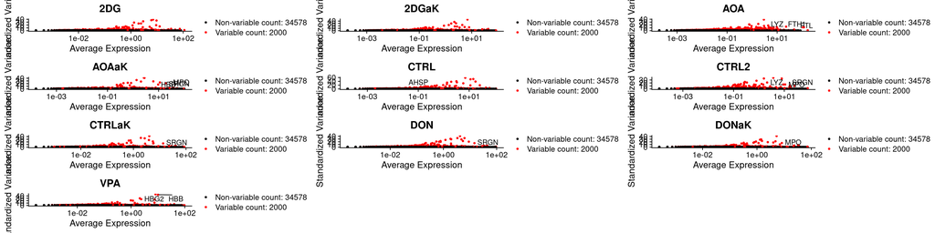

```r
# Initialize empty output list
features_plot_list = list()
features_gene_list = list()

#
for (i in 1:number_conditions) {

  name_obj = names(list_seurat_obj)[i]
  variable_genes = VariableFeatures(list_seurat_obj[[i]])
  features_gene_list[[i]] = variable_genes

   plot_vfeature = LabelPoints(plot = VariableFeaturePlot(list_seurat_obj[[i]]),
                               points = head(variable_genes, 20),
                               repel = TRUE) +
    theme(plot.background = element_rect(fill = "white")) +
    ggtitle(name_obj)
  features_plot_list[[i]] = plot_vfeature

}

grid.arrange(grobs = features_plot_list, ncol = 3)
```

```r
names(features_plot_list) = names(list_seurat_obj)
names(features_gene_list) = names(list_seurat_obj)
```

## ScaleData()

linear transformation Shifts the expression of each gene, so that the mean expression across cells is 0 Scales the expression of each gene, so that the variance across cells is 1 This step gives equal weight in downstream analyses, so that highly-expressed genes do not dominate Pour le fait de faire un scaling différent en fonction du orig.ident, pourquoi pas. Ca peut potentiellement tirer un peu sur les gènes qui ont des grosses disparités entre conditions pour la PCA, mais c’est pas forcément un mal car c’est ce qui t’intéresse. Setting center to TRUE will center the expression for each feature by subtracting the average expression for that feature. Setting scale to TRUE will scale the expression level for each feature by dividing the centered feature expression levels by their standard deviations if center is TRUE and by their root mean square otherwise. Since highly expressed genes exhibit the highest amount of variation and we don’t want our ‘highly variable genes’ only to reflect high expression, we need to scale the data to scale variation with expression level. The Seurat ScaleData() function will scale the data by: adjusting the expression of each gene to give a mean expression across cells to be 0 scaling expression of each gene to give a variance across cells to be 1 https://hbctraining.github.io/scRNA-seq_online/lessons/06_SC_SCT_normalization.html premier scale sans régression, il est possible de refaire un autre scale après en rajoutant une régression = > therefore overwriting the output of ScaleData()

```r
list_seurat_obj = lapply(list_seurat_obj, function(x) {
  ScaleData(object = x,
            assay = "RNA",
            split.by = "orig.ident",
            verbose = TRUE)
})
```

# Etude de l’influence du cycle cellulaire sur les variations observées

Pour étudier le cycle cellulaire, les données doivent avoir été préalablement normalisées et mises à l’échelle. On utilise ensuite une liste de gènes (contenue dans la fonction Seurat cc.genes) associés aux phases du cycle cellulaire S et G2M, pour associer un score à chaque cellule les plaçant dans une phase ou l’autre. Les marqueurs sont anticorrélés dans les cellules et celles qui n’en expriment aucun ne sont pas en phase de division ou alors sont en phase G1.  
L’identification de la phase du cycle cellulaire pour les cellules permettra de ” mitigate the effects of cell cycle heterogeneity in scRNA-seq data by calculating cell cycle phase scores based on canonical markers, and regressing these out of the data during pre-processing.”.

```r
cat("There are", length(cc.genes$s.genes),
    "markers associated to S phase :", "\n",
    cc.genes$s.genes, "\n")
```

```
## There are 43 markers associated to S phase :
##  MCM5 PCNA TYMS FEN1 MCM2 MCM4 RRM1 UNG GINS2 MCM6 CDCA7 DTL PRIM1 UHRF1 MLF1IP HELLS RFC2 RPA2 NASP RAD51AP1 GMNN WDR76 SLBP CCNE2 UBR7 POLD3 MSH2 ATAD2 RAD51 RRM2 CDC45 CDC6 EXO1 TIPIN DSCC1 BLM CASP8AP2 USP1 CLSPN POLA1 CHAF1B BRIP1 E2F8
```

```r
cat("There are", length(cc.genes$g2m.genes),
    "markers associated to G2M phase :", "\n",
    cc.genes$g2m.genes, "\n")
```

[output not shown]

## Attribution d’un score de cycle cellulaire pour les cellules

```r
list_seurat_obj = lapply(list_seurat_obj, function(x) {
  CellCycleScoring(object = x,
                   assay = "RNA",
                   s.features = cc.genes$s.genes,
                   g2m.features = cc.genes$g2m.genes,
                   set.ident = TRUE,
                   verbose = TRUE)
})
```

## Répartition des cellules sur la base de leur score de cycle cellulaire

```r
list_seurat_obj = lapply(list_seurat_obj, function(x) {
  RunPCA(object = x,
         assay = "RNA",
         reduction.name = "pca.cellcycle",
         npcs = 50,
         features = c(cc.genes$s.genes, cc.genes$g2m.genes),
         verbose = TRUE)
})
```

[output not shown]

[output not shown]

[output not shown]

[output not shown]

[output not shown]

[output not shown]

[output not shown]

[output not shown]

[output not shown]

[output not shown]

```r
tab_cellcycle = data.frame()

for (i in 1:number_conditions) {

  name_cond = names(list_seurat_obj[i])
  tab = as.data.frame(table(list_seurat_obj[[i]]$Phase)) %>%
    tidyr::pivot_wider(names_from ="Var1", values_from = "Freq") %>%
    dplyr::mutate(condition = name_cond)
  tab_cellcycle = rbind(tab_cellcycle, tab)
}

tab_cellcycle %>%
  kable() %>%
  kable_styling()
```

| G1 | G2M | S | condition |
| --- | --- | --- | --- |
| 2136 | 1031 | 1060 | 2DG |
| 2182 | 1568 | 1626 | 2DGaK |
| 3481 | 307 | 1338 | AOA |
| 1898 | 2269 | 2185 | AOAaK |
| 2207 | 1982 | 1786 | CTRL |
| 5165 | 1322 | 2023 | CTRL2 |
| 1878 | 1725 | 1508 | CTRLaK |
| 1318 | 1388 | 1273 | DON |
| 1393 | 1249 | 1288 | DONaK |
| 1457 | 1091 | 925 | VPA |

## Visualisation du score de cycle cellulaire

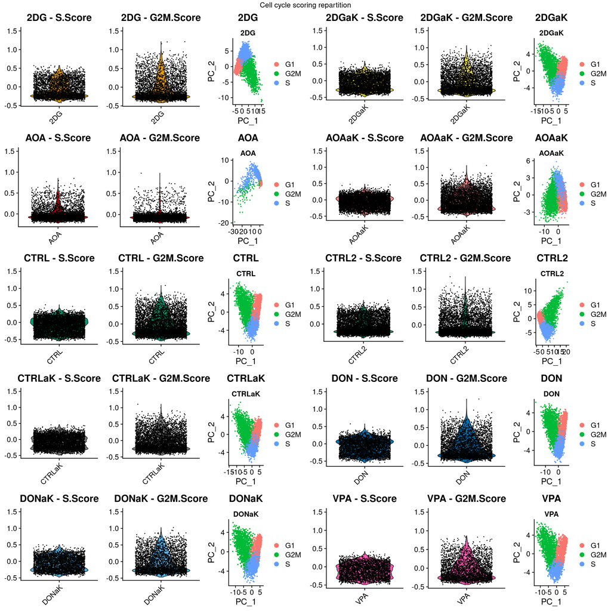

```r
# initialize list
plot_cc_list = list()

for (i in 1:number_conditions) {

  name_obj = names(list_seurat_obj)[i]

  plot.s = VlnPlot(object = list_seurat_obj[[i]], features = "S.Score",
                   group.by = "orig.ident", pt.size = 0.1,
                   assay = "RNA", y.max = 1.5,
                   same.y.lims = TRUE) +
    scale_fill_manual(values = color_code, limits = force) +
    ggtitle(paste0(name_obj, " - S.Score")) +
    NoLegend() +
    theme(axis.title.x = element_blank())

  plot.g2 = VlnPlot(object = list_seurat_obj[[i]], features = "G2M.Score",
                    group.by = "orig.ident", pt.size = 0.1,
                    assay = "RNA", y.max = 1.5,
                    same.y.lims = TRUE) +
    scale_fill_manual(values = color_code, limits = force) +
    ggtitle(paste0(name_obj, " - G2M.Score")) +
    NoLegend() +
    theme(axis.title.x = element_blank())

    cc_cond_pca = DimPlot(object = list_seurat_obj[[i]],
                        reduction = "pca.cellcycle",
                        group.by = "Phase",
                        split.by = "orig.ident") + ggtitle(name_obj)

  plot_cc_list[[i]] = list(plot.s, plot.g2, cc_cond_pca)

}


grid.arrange(grobs = unlist(plot_cc_list, recursive = FALSE),
             ncol = 6,
             top = textGrob("Cell cycle scoring repartition"))
```

## Déterminer le nombre d’UMI impliqués dans les gènes du cycle cellulaire

```r
# Liste de matrices (gène/cellule/nbUMI) par condition
list_mat = lapply(list_seurat_obj, function(x) {
  as.data.frame(x@assays$RNA@counts)
})
# Restriction des tableaux aux gènes du cycle cellulaire
print("Filter genes to keep only cell cycle genes")
```

```
## [1] "Filter genes to keep only cell cycle genes"
```

```r
list_mat = lapply(list_mat, function(x) {
  x %>% dplyr::filter(row.names(x) %in% c(cc.genes$s.genes, cc.genes$g2m.genes))
})

# Extraction du nombre de cellules détectant chaque gène et
# des statistiques sur les UMI (total, moyenne, médiane, variance)
print("Calculate tab statistics")
```

```
## [1] "Calculate tab statistics"
```

```r
list_mat = lapply(list_mat, function(x) {
    print("Calculate temp_nbcells tab")
    temp_nbcells = x
    ncol_temp_nbcells = ncol(temp_nbcells)
    temp_nbcells[] = lapply(temp_nbcells, as.logical)
    temp_nbcells = temp_nbcells %>%
      dplyr::mutate(nbcells = rowSums(.)) %>%
      dplyr::mutate(percentcells = round((nbcells/ncol_temp_nbcells) *100)) %>%
      tibble::rownames_to_column(var = "gene") %>%
      dplyr::select(gene, nbcells, percentcells)
    print("Calculate temp_umi tab")
    temp_umi = x
    temp_umi = temp_umi %>%
      dplyr::mutate(totalUMI = rowSums(.),
                    medianUMI = rowMedians(as.matrix(temp_umi[,-totalUMI])),
                    meanUMI = round(rowMeans(as.matrix(temp_umi[,c(-totalUMI, -medianUMI)])), 2),
                    varUMI = round(rowVars(as.matrix(temp_umi[,c(-totalUMI, -medianUMI, -meanUMI)])), 2)) %>%
      tibble::rownames_to_column(var = "gene") %>%
      dplyr::mutate(phase = ifelse(gene %in% cc.genes$s.genes, "S", "G2M")) %>%
      dplyr::select(gene, phase, totalUMI, meanUMI, medianUMI, varUMI)
    x = full_join(temp_nbcells, temp_umi, by = "gene")
    return(x)
  })
```

```
## [1] "Calculate temp_nbcells tab"
## [1] "Calculate temp_umi tab"
## [1] "Calculate temp_nbcells tab"
## [1] "Calculate temp_umi tab"
## [1] "Calculate temp_nbcells tab"
## [1] "Calculate temp_umi tab"
## [1] "Calculate temp_nbcells tab"
## [1] "Calculate temp_umi tab"
## [1] "Calculate temp_nbcells tab"
## [1] "Calculate temp_umi tab"
## [1] "Calculate temp_nbcells tab"
## [1] "Calculate temp_umi tab"
## [1] "Calculate temp_nbcells tab"
## [1] "Calculate temp_umi tab"
## [1] "Calculate temp_nbcells tab"
## [1] "Calculate temp_umi tab"
## [1] "Calculate temp_nbcells tab"
## [1] "Calculate temp_umi tab"
## [1] "Calculate temp_nbcells tab"
## [1] "Calculate temp_umi tab"
```

```r
# Groupement des tableaux des conditions dans un tableau général
tab_cc = dplyr::bind_rows(list_mat, .id = "condition")

tab_cc %>%
      kable(caption = name_obj) %>%
      kable_styling() %>%
      scroll_box(height = "400px", width = "100%")
```

VPA

| condition | gene | nbcells | percentcells | phase | totalUMI | meanUMI | medianUMI | varUMI |
| --- | --- | --- | --- | --- | --- | --- | --- | --- |
| 2DG | RPA2 | 1764 | 42 | S | 2660 | 0.63 | 0 | 0.86 |
| 2DG | CLSPN | 1737 | 41 | S | 5105 | 1.21 | 0 | 3.99 |
| 2DG | CDCA8 | 1089 | 26 | G2M | 2019 | 0.48 | 0 | 1.07 |
| 2DG | CDC20 | 1163 | 28 | G2M | 2642 | 0.63 | 0 | 2.05 |
| 2DG | KIF2C | 1013 | 24 | G2M | 1772 | 0.42 | 0 | 0.84 |
| 2DG | NASP | 3455 | 82 | S | 18377 | 4.35 | 3 | 22.53 |
| 2DG | USP1 | 2646 | 63 | S | 7093 | 1.68 | 1 | 4.16 |
| 2DG | PSRC1 | 248 | 6 | G2M | 313 | 0.07 | 0 | 0.11 |
| 2DG | ANP32E | 2767 | 65 | G2M | 9759 | 2.31 | 1 | 8.45 |
| 2DG | CKS1B | 2258 | 53 | G2M | 6456 | 1.53 | 1 | 4.63 |
| 2DG | NUF2 | 1027 | 24 | G2M | 1734 | 0.41 | 0 | 0.79 |
| 2DG | NEK2 | 579 | 14 | G2M | 829 | 0.20 | 0 | 0.34 |
| 2DG | DTL | 1130 | 27 | S | 1828 | 0.44 | 0 | 0.79 |
| 2DG | CENPF | 2296 | 54 | G2M | 15828 | 3.75 | 1 | 50.19 |
| 2DG | LBR | 2667 | 63 | G2M | 6753 | 1.60 | 1 | 3.83 |
| 2DG | EXO1 | 654 | 15 | S | 888 | 0.21 | 0 | 0.33 |
| 2DG | RRM2 | 1676 | 40 | S | 5331 | 1.26 | 0 | 5.14 |
| 2DG | CENPA | 736 | 17 | G2M | 1347 | 0.32 | 0 | 0.74 |
| 2DG | MSH2 | 1855 | 44 | S | 3321 | 0.79 | 0 | 1.41 |
| 2DG | BUB1 | 1152 | 27 | G2M | 2189 | 0.52 | 0 | 1.25 |
| 2DG | CKAP2L | 1037 | 25 | G2M | 1872 | 0.44 | 0 | 0.93 |
| 2DG | MCM6 | 1787 | 42 | S | 4030 | 0.96 | 0 | 2.41 |
| 2DG | CDCA7 | 1771 | 42 | S | 3279 | 0.78 | 0 | 1.50 |
| 2DG | HJURP | 961 | 23 | G2M | 1813 | 0.43 | 0 | 1.00 |
| 2DG | MCM2 | 1389 | 33 | S | 2368 | 0.56 | 0 | 1.01 |
| 2DG | SMC4 | 2737 | 65 | G2M | 10123 | 2.39 | 1 | 9.52 |
| 2DG | ECT2 | 859 | 20 | G2M | 1268 | 0.30 | 0 | 0.50 |
| 2DG | SLBP | 2227 | 53 | S | 5021 | 1.19 | 1 | 2.68 |
| 2DG | TACC3 | 1671 | 40 | G2M | 3579 | 0.85 | 0 | 2.15 |
| 2DG | CENPE | 1352 | 32 | G2M | 4383 | 1.04 | 0 | 5.33 |

[output cut: 910 more lines]

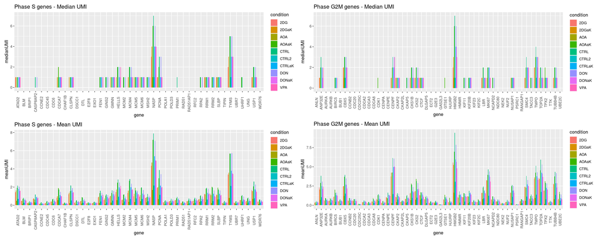

```r
plot_smedian = ggplot(tab_cc %>% filter(phase == "S"),
                      aes(x=gene, y=medianUMI, fill=condition)) +
  geom_col(position = "dodge") +
  theme(axis.text.x = element_text(angle = 90, vjust = 0.5)) +
  #scale_fill_manual(values = color_code, limits = force) +
  ggtitle("Phase S genes - Median UMI")

plot_smean = ggplot(tab_cc %>% filter(phase == "S"),
                    aes(x=gene, y=meanUMI, fill=condition)) +
    geom_col(position = "dodge") +
    theme(axis.text.x = element_text(angle = 90, vjust = 0.5)) +
   #scale_fill_manual(values = color_code, limits = force) +
    ggtitle("Phase S genes - Mean UMI")

plot_g2median = ggplot(tab_cc %>% filter(phase == "G2M"),
                       aes(x=gene, y=medianUMI, fill=condition)) +
    geom_col(position = "dodge") +
    theme(axis.text.x = element_text(angle = 90, vjust = 0.5)) +
   #scale_fill_manual(values = color_code, limits = force) +
    ggtitle("Phase G2M genes - Median UMI")

plot_g2mean = ggplot(tab_cc %>% filter(phase == "G2M"),
                     aes(x=gene, y=meanUMI, fill=condition)) +
    geom_col(position = "dodge") +
    theme(axis.text.x = element_text(angle = 90, vjust = 0.5)) +
   #scale_fill_manual(values = color_code, limits = force) +
    ggtitle("Phase G2M genes - Mean UMI")

print(plot_smedian/plot_smean | plot_g2median/plot_g2mean)
```

Possibilité de régresser les données ou non => la régression se fait au niveau de la normalisation SCT.

# Normalisation de l’assay RNA avec SCTransform

“Compared to basic Seurat normalisation + scaling + variable gene finding, the SCTransform workflow performs more effective normalization, strongly removing technical effects from the data. This allows more PCs to be selected in the PCA step, as the higher PCs are more likely to represent subtle, but biologically relevant, sources of heterogeneity instead of variation in sequencing depth.”

```r
# On ne peut pas faire les deux normalisations dans le même objets car la deuxième efface la première

# SC normalization with cell cycle regression
list_seurat_obj_cc = lapply(list_seurat_obj, function(x) {
  SCTransform(object = x,
              assay = "RNA",
              # new.assay.name = "SCT_with_ccreg",
              new.assay.name = "SCT",
              method = "glmGamPoi",
              do.center = TRUE,
              do.scale = FALSE,
              variable.features.n = 3000,
              vars.to.regress = c("S.Score", "G2M.Score"),
              min_cells = 1,
              ncells = NULL,
              verbose = FALSE)
})

# SC normalization without cell cycle regression
list_seurat_obj = lapply(list_seurat_obj, function(x) {
  SCTransform(object = x,
              assay = "RNA",
              # new.assay.name = "SCT_without_ccreg",
              new.assay.name = "SCT",
              method = "glmGamPoi",
              do.center = TRUE,
              do.scale = FALSE,
              variable.features.n = 3000,
              vars.to.regress = NULL,
              min_cells = 1,
              ncells = NULL,
              verbose = FALSE)

})
```